# PaganWalker_Project_Part_III

## Part III:

### Reading saved Cassandra data into Elasticsearch

#### Start with reading the data out of Cassandra into Spark.

```python
import pyspark
from pyspark.sql import SparkSession
print('ready')
```

```
ready
```

#### Start a new session and save the new copies to Elasticsearch

```python
# ELASTICSEARCH CONFIGURATION
elastic_host = "elasticsearch"
elastic_port = "9200"
spark = SparkSession.builder \
    .master("local") \
    .appName('jupyter-pyspark') \
    .config("spark.jars.packages","org.elasticsearch:elasticsearch-spark-20_2.12:7.15.0")\
    .config("spark.es.nodes", elastic_host) \
    .config("spark.es.port",elastic_port) \
    .getOrCreate()
sc = spark.sparkContext
sc.setLogLevel("ERROR")
print(f"host {elastic_host}, port{elastic_port}")
```

```
host elasticsearch, port9200
```

```python
childcare = spark.read.json("/home/jovyan/Walker-Labs/Project/datasets/childcare.json")

childcare.write.mode("Overwrite").format("es").save("childcare/_doc")
childcare.toPandas()
```

|  | county_name | infant_center_based_price_2018_dollar | infant_center_based_price_as_share_of_family_income_2018_percent | infant_home_based_price_2018_dollar | infant_home_based_price_as_share_of_family_income_2018_percent | median_family_income_dollar | percent_asian_percent | percent_black_percent | percent_hispanic_of_any_race_percent | percent_of_families_in_poverty_percent | ... | school_age_home_based_price_2018_dollar | school_age_home_based_price_as_share_of_family_income_2018_percent | state_name | toddler_center_based_price_2018_dollar | toddler_center_based_price_as_share_of_family_income_2018_percent | toddler_home_based_price_2018_dollar | toddler_home_based_price_as_share_of_family_income_2018_percent | total_population | womens_labor_force_participation_rate_percent | womens_median_earnings_dollar |
| --- | --- | --- | --- | --- | --- | --- | --- | --- | --- | --- | --- | --- | --- | --- | --- | --- | --- | --- | --- | --- | --- |
| 0 | Adair County | 6583.72 | 15.911545 | 4958.72 | 11.984243 | 41377.0 | 0.7 | 0.3 | 6.6 | 23.2 | ... | 3705.00 | 8.954250 | Oklahoma | 5535.40 | 13.377964 | 4815.72 | 11.638640 | 22113 | 58.3 | 23033.0 |
| 1 | Alfalfa County | 7929.48 | 11.652261 | 5969.08 | 8.771480 | 68051.0 | 0.0 | 3.3 | 5.3 | 5.4 | ... | 4457.44 | 6.550146 | Oklahoma | 6665.36 | 9.794654 | 5796.96 | 8.518552 | 5857 | 68.8 | 22112.0 |
| 2 | Atoka County | 6705.40 | 14.399467 | 5053.36 | 10.851805 | 46567.0 | 0.6 | 3.9 | 3.5 | 16.0 | ... | 3779.88 | 8.117079 | Oklahoma | 5639.92 | 12.111409 | 4907.76 | 10.539137 | 13874 | 61.1 | 23214.0 |
| 3 | Beaver County | 7760.48 | 13.160717 | 5842.72 | 9.908457 | 58967.0 | 0.0 | 0.3 | 23.0 | 9.2 | ... | 4363.32 | 7.399596 | Oklahoma | 6523.92 | 11.063680 | 5674.24 | 9.622738 | 5415 | 62.7 | 21181.0 |
| 4 | Beckham County | 7985.64 | 12.439660 | 6014.32 | 9.368829 | 64195.0 | 0.8 | 3.8 | 14.5 | 7.8 | ... | 4493.84 | 7.000296 | Oklahoma | 6714.24 | 10.459132 | 5840.64 | 9.098279 | 22621 | 61.6 | 22872.0 |
| ... | ... | ... | ... | ... | ... | ... | ... | ... | ... | ... | ... | ... | ... | ... | ... | ... | ... | ... | ... | ... | ... |
| 3137 | Wayne County | 6605.04 | 13.877884 | 5070.00 | 10.652603 | 47594.0 | 0.4 | 6.8 | 2.0 | 17.0 | ... | 3640.00 | 7.648023 | Tennessee | 5720.00 | 12.018322 | 5070.00 | 10.652603 | 16649 | 65.3 | 20403.0 |
| 3138 | Weakley County | 6605.04 | 12.590141 | 5070.00 | 9.664138 | 52462.0 | 0.2 | 8.6 | 2.4 | 13.5 | ... | 3640.00 | 6.938355 | Tennessee | 5720.00 | 10.903130 | 5070.00 | 9.664138 | 33626 | 65.6 | 20430.0 |
| 3139 | White County | 6605.04 | 13.673899 | 5070.00 | 10.496025 | 48304.0 | 0.2 | 2.0 | 2.5 | 12.9 | ... | 3640.00 | 7.535608 | Tennessee | 5720.00 | 11.841669 | 5070.00 | 10.496025 | 26580 | 62.0 | 25057.0 |
| 3140 | Williamson County | 9620.00 | 7.852997 | 7020.00 | 5.730565 | 122501.0 | 4.1 | 4.3 | 4.7 | 2.9 | ... | 3380.00 | 2.759161 | Tennessee | 7676.76 | 6.266692 | 6383.00 | 5.210570 | 218648 | 70.6 | 35800.0 |
| 3141 | Wilson County | 9620.00 | 11.750623 | 7020.00 | 8.574779 | 81868.0 | 1.5 | 7.0 | 4.0 | 6.1 | ... | 3380.00 | 4.128597 | Tennessee | 7676.76 | 9.376997 | 6383.00 | 7.796697 | 132663 | 73.9 | 31975.0 |

3142 rows × 27 columns

```python
labor = spark.read.json("/home/jovyan/Walker-Labs/Project/datasets/labor.json")

labor.write.mode("Overwrite").format("es").save("labor/_doc")
labor.toPandas()
```

|  | Age Group | Ethnicity | Gender | age_sex_race_ethnicity | employed_full_time_workers_at_work_35hrs_or_more | employed_full_time_workers_at_work_less_than_35hrs | employed_full_time_workers_not_at_work | employed_full_time_workers_total | employed_part_time_for_economic_reasons | employed_part_time_for_non_economic_reasons | employed_part_time_not_at_work | employed_part_time_workers_total | unemployed_looking_for_full_time_work | unemployed_looking_for_part_time_work |
| --- | --- | --- | --- | --- | --- | --- | --- | --- | --- | --- | --- | --- | --- | --- |
| 0 | 16 years and over | Black or African American | Women | Women, 16 years and over | 7261.0 | 617.0 | 275.0 | 8154.0 | 365.0 | 1454.0 | 101.0 | 1920.0 | 534.0 | 112.0 |
| 1 | 16 to 19 years | Black or African American | Women | 16 to 19 years | 82.0 | 10.0 | 3.0 | 95.0 | 14.0 | 205.0 | 8.0 | 227.0 | 39.0 | 34.0 |
| 2 | 20 years and over | Black or African American | Women | 20 years and over | 7179.0 | 607.0 | 272.0 | 8058.0 | 350.0 | 1250.0 | 93.0 | 1693.0 | 495.0 | 79.0 |
| 3 | 20 to 24 years | Black or African American | Women | 20 to 24 years | 595.0 | 51.0 | 22.0 | 667.0 | 73.0 | 272.0 | 15.0 | 360.0 | 86.0 | 15.0 |
| 4 | 25 years and over | Black or African American | Women | 25 years and over | 6584.0 | 557.0 | 250.0 | 7391.0 | 278.0 | 977.0 | 78.0 | 1333.0 | 409.0 | 64.0 |
| 5 | 25 to 54 years | Black or African American | Women | 25 to 54 years | 5243.0 | 423.0 | 194.0 | 5861.0 | 226.0 | 681.0 | 58.0 | 964.0 | 344.0 | 47.0 |
| 6 | 55 years and over | Black or African American | Women | 55 years and over | 1341.0 | 133.0 | 56.0 | 1530.0 | 52.0 | 296.0 | 21.0 | 368.0 | 64.0 | 17.0 |
| 7 | 16 years and over | Black or African American | Men | Men, 16 years and over | 7239.0 | 463.0 | 197.0 | 7899.0 | 299.0 | 759.0 | 61.0 | 1119.0 | 591.0 | 85.0 |
| 8 | 16 to 19 years | Black or African American | Men | 16 to 19 years | 89.0 | 14.0 | 0.0 | 103.0 | 24.0 | 140.0 | 6.0 | 170.0 | 60.0 | 34.0 |
| 9 | 20 years and over | Black or African American | Men | 20 years and over | 7150.0 | 450.0 | 197.0 | 7797.0 | 274.0 | 619.0 | 55.0 | 948.0 | 531.0 | 51.0 |
| 10 | 20 to 24 years | Black or African American | Men | 20 to 24 years | 610.0 | 42.0 | 7.0 | 659.0 | 64.0 | 180.0 | 10.0 | 254.0 | 118.0 | 14.0 |
| 11 | 25 years and over | Black or African American | Men | 25 years and over | 6540.0 | 407.0 | 190.0 | 7137.0 | 211.0 | 439.0 | 45.0 | 695.0 | 412.0 | 37.0 |
| 12 | 25 to 54 years | Black or African American | Men | 25 to 54 years | 5252.0 | 312.0 | 139.0 | 5704.0 | 181.0 | 276.0 | 30.0 | 487.0 | 345.0 | 24.0 |
| 13 | 55 years and over | Black or African American | Men | 55 years and over | 1288.0 | 95.0 | 51.0 | 1434.0 | 30.0 | 164.0 | 15.0 | 208.0 | 68.0 | 13.0 |
| 14 | 16 years and over | Hispanic or Latino | Women | Women, 16 years and over | 7707.0 | 691.0 | 296.0 | 8694.0 | 508.0 | 2270.0 | 123.0 | 2901.0 | 465.0 | 163.0 |
| 15 | 16 to 19 years | Hispanic or Latino | Women | 16 to 19 years | 120.0 | 17.0 | 2.0 | 140.0 | 33.0 | 361.0 | 15.0 | 409.0 | 33.0 | 49.0 |
| 16 | 20 years and over | Hispanic or Latino | Women | 20 years and over | 7587.0 | 673.0 | 293.0 | 8554.0 | 475.0 | 1909.0 | 107.0 | 2491.0 | 432.0 | 115.0 |
| 17 | 20 to 24 years | Hispanic or Latino | Women | 20 to 24 years | 784.0 | 78.0 | 28.0 | 890.0 | 96.0 | 454.0 | 16.0 | 566.0 | 76.0 | 27.0 |
| 18 | 25 years and over | Hispanic or Latino | Women | 25 years and over | 6803.0 | 595.0 | 265.0 | 7664.0 | 379.0 | 1455.0 | 91.0 | 1926.0 | 356.0 | 88.0 |
| 19 | 25 to 54 years | Hispanic or Latino | Women | 25 to 54 years | 5752.0 | 497.0 | 219.0 | 6468.0 | 299.0 | 1143.0 | 70.0 | 1512.0 | 299.0 | 71.0 |
| 20 | 55 years and over | Hispanic or Latino | Women | 55 years and over | 1051.0 | 99.0 | 47.0 | 1196.0 | 80.0 | 312.0 | 22.0 | 414.0 | 57.0 | 17.0 |
| 21 | 16 years and over | Hispanic or Latino | Men | Men, 16 years and over | 12502.0 | 916.0 | 301.0 | 13719.0 | 438.0 | 1207.0 | 54.0 | 1699.0 | 601.0 | 94.0 |
| 22 | 16 to 19 years | Hispanic or Latino | Men | 16 to 19 years | 201.0 | 25.0 | 4.0 | 230.0 | 29.0 | 278.0 | 8.0 | 315.0 | 57.0 | 47.0 |
| 23 | 20 years and over | Hispanic or Latino | Men | 20 years and over | 12301.0 | 891.0 | 298.0 | 13489.0 | 408.0 | 930.0 | 46.0 | 1384.0 | 544.0 | 47.0 |
| 24 | 20 to 24 years | Hispanic or Latino | Men | 20 to 24 years | 1170.0 | 86.0 | 20.0 | 1276.0 | 87.0 | 333.0 | 9.0 | 429.0 | 120.0 | 16.0 |
| 25 | 25 years and over | Hispanic or Latino | Men | 25 years and over | 11131.0 | 805.0 | 277.0 | 12213.0 | 321.0 | 597.0 | 37.0 | 955.0 | 424.0 | 31.0 |
| 26 | 25 to 54 years | Hispanic or Latino | Men | 25 to 54 years | 9410.0 | 676.0 | 221.0 | 10306.0 | 268.0 | 420.0 | 24.0 | 712.0 | 336.0 | 20.0 |
| 27 | 55 years and over | Hispanic or Latino | Men | 55 years and over | 1721.0 | 129.0 | 57.0 | 1907.0 | 53.0 | 177.0 | 13.0 | 243.0 | 88.0 | 11.0 |
| 28 | 16 years and over | White | Women | Women, 16 years and over | 36781.0 | 3541.0 | 1504.0 | 41825.0 | 1363.0 | 11740.0 | 831.0 | 13934.0 | 1414.0 | 560.0 |
| 29 | 16 to 19 years | White | Women | 16 to 19 years | 386.0 | 62.0 | 9.0 | 457.0 | 92.0 | 1453.0 | 74.0 | 1620.0 | 85.0 | 145.0 |
| 30 | 20 years and over | White | Women | 20 years and over | 36395.0 | 3480.0 | 1494.0 | 41369.0 | 1271.0 | 10286.0 | 756.0 | 12313.0 | 1329.0 | 415.0 |
| 31 | 20 to 24 years | White | Women | 20 to 24 years | 2834.0 | 270.0 | 83.0 | 3187.0 | 256.0 | 1618.0 | 77.0 | 1950.0 | 213.0 | 82.0 |
| 32 | 25 years and over | White | Women | 25 years and over | 33561.0 | 3209.0 | 1412.0 | 38182.0 | 1015.0 | 8669.0 | 680.0 | 10363.0 | 1116.0 | 333.0 |
| 33 | 25 to 54 years | White | Women | 25 to 54 years | 25121.0 | 2311.0 | 1020.0 | 28451.0 | 768.0 | 5181.0 | 389.0 | 6338.0 | 851.0 | 214.0 |
| 34 | 55 years and over | White | Women | 55 years and over | 8441.0 | 898.0 | 392.0 | 9731.0 | 247.0 | 3488.0 | 291.0 | 4026.0 | 265.0 | 119.0 |
| 35 | 16 years and over | White | Men | Men, 16 years and over | 52678.0 | 3849.0 | 1487.0 | 58015.0 | 1183.0 | 6083.0 | 421.0 | 7687.0 | 1998.0 | 383.0 |
| 36 | 16 to 19 years | White | Men | 16 to 19 years | 610.0 | 74.0 | 18.0 | 702.0 | 90.0 | 1139.0 | 53.0 | 1281.0 | 139.0 | 147.0 |
| 37 | 20 years and over | White | Men | 20 years and over | 52068.0 | 3775.0 | 1470.0 | 57312.0 | 1093.0 | 4944.0 | 369.0 | 6406.0 | 1858.0 | 235.0 |
| 38 | 20 to 24 years | White | Men | 20 to 24 years | 3763.0 | 285.0 | 63.0 | 4111.0 | 251.0 | 1153.0 | 45.0 | 1450.0 | 332.0 | 58.0 |
| 39 | 25 years and over | White | Men | 25 years and over | 48305.0 | 3489.0 | 1406.0 | 53201.0 | 842.0 | 3791.0 | 323.0 | 4957.0 | 1526.0 | 177.0 |
| 40 | 25 to 54 years | White | Men | 25 to 54 years | 36068.0 | 2480.0 | 928.0 | 39476.0 | 644.0 | 1587.0 | 112.0 | 2343.0 | 1140.0 | 75.0 |
| 41 | 55 years and over | White | Men | 55 years and over | 12238.0 | 1009.0 | 479.0 | 13726.0 | 198.0 | 2204.0 | 211.0 | 2613.0 | 386.0 | 102.0 |
| 42 | 16 years and over | Asian | Women | Women, 16 years and over | 3356.0 | 250.0 | 127.0 | 3733.0 | 95.0 | 754.0 | 63.0 | 911.0 | 117.0 | 29.0 |
| 43 | 16 to 19 years | Asian | Women | 16 to 19 years | 17.0 | 2.0 | 0.0 | 19.0 | 3.0 | 55.0 | 4.0 | 62.0 | 3.0 | 7.0 |
| 44 | 20 years and over | Asian | Women | 20 years and over | 3340.0 | 248.0 | 127.0 | 3714.0 | 92.0 | 698.0 | 59.0 | 849.0 | 114.0 | 22.0 |
| 45 | 20 to 24 years | Asian | Women | 20 to 24 years | 181.0 | 12.0 | 4.0 | 196.0 | 14.0 | 114.0 | 7.0 | 134.0 | 22.0 | 5.0 |
| 46 | 25 years and over | Asian | Women | 25 years and over | 3159.0 | 236.0 | 123.0 | 3518.0 | 78.0 | 585.0 | 53.0 | 715.0 | 93.0 | 17.0 |
| 47 | 25 to 54 years | Asian | Women | 25 to 54 years | 2524.0 | 179.0 | 98.0 | 2801.0 | 61.0 | 422.0 | 35.0 | 518.0 | 75.0 | 12.0 |
| 48 | 55 years and over | Asian | Women | 55 years and over | 635.0 | 57.0 | 25.0 | 717.0 | 17.0 | 163.0 | 17.0 | 197.0 | 18.0 | 5.0 |
| 49 | 16 years and over | Asian | Men | Men, 16 years and over | 4307.0 | 251.0 | 104.0 | 4661.0 | 77.0 | 425.0 | 24.0 | 527.0 | 140.0 | 19.0 |
| 50 | 16 to 19 years | Asian | Men | 16 to 19 years | 20.0 | 2.0 | 0.0 | 22.0 | 3.0 | 57.0 | 3.0 | 63.0 | 3.0 | 4.0 |
| 51 | 20 years and over | Asian | Men | 20 years and over | 4287.0 | 249.0 | 103.0 | 4639.0 | 74.0 | 368.0 | 22.0 | 464.0 | 137.0 | 15.0 |
| 52 | 20 to 24 years | Asian | Men | 20 to 24 years | 190.0 | 15.0 | 4.0 | 209.0 | 14.0 | 104.0 | 3.0 | 121.0 | 26.0 | 7.0 |
| 53 | 25 years and over | Asian | Men | 25 years and over | 4097.0 | 234.0 | 99.0 | 4430.0 | 60.0 | 264.0 | 19.0 | 343.0 | 112.0 | 8.0 |
| 54 | 25 to 54 years | Asian | Men | 25 to 54 years | 3321.0 | 184.0 | 70.0 | 3575.0 | 40.0 | 161.0 | 10.0 | 211.0 | 87.0 | 5.0 |
| 55 | 55 years and over | Asian | Men | 55 years and over | 776.0 | 50.0 | 29.0 | 855.0 | 20.0 | 103.0 | 8.0 | 132.0 | 24.0 | 3.0 |

```python
income = spark.read.json("/home/jovyan/Walker-Labs/Project/datasets/nces.json")

income.write.mode("Overwrite").format("es").save("income/_doc")
income.toPandas()
```

|  | median_income_1990 | median_income_2000 | median_income_2005 | median_income_2010 | median_income_2015 | median_income_2016 | median_income_2017 | median_income_2018 | median_income_2019 | median_income_2021 | state_name | std_error_2005 | std_error_2010 | std_error_2015 | std_error_2016 | std_error_2017 | std_error_2018 | std_error_2019 | std_error_2021 |
| --- | --- | --- | --- | --- | --- | --- | --- | --- | --- | --- | --- | --- | --- | --- | --- | --- | --- | --- | --- |
| 0 | 62300.0 | 71400.0 | 65500.0 | 61000.0 | 63600.0 | 64100.0 | 65500.0 | 65600.0 | 68000.0 | 67100.0 | Wisconsin | 330.0 | 380.0 | 300.0 | 380.0 | 390.0 | 260.0 | 390.0 | 370.0 |
| 1 | 47700.0 | 54900.0 | 52000.0 | 49900.0 | 51700.0 | 52700.0 | 53500.0 | 54200.0 | 55400.0 | 55600.0 | Kentucky | 400.0 | 380.0 | 330.0 | 410.0 | 420.0 | 370.0 | 400.0 | 430.0 |
| 2 | 58900.0 | 60700.0 | 59500.0 | 57100.0 | 58900.0 | 59900.0 | 62200.0 | 60000.0 | 62400.0 | 64800.0 | Maine | 820.0 | 720.0 | 590.0 | 950.0 | 780.0 | 870.0 | 1130.0 | 760.0 |
| 3 | 57600.0 | 66700.0 | 59700.0 | 58000.0 | 61900.0 | 65000.0 | 66600.0 | 68400.0 | 71100.0 | 71600.0 | Oregon | 490.0 | 410.0 | 630.0 | 590.0 | 530.0 | 690.0 | 560.0 | 640.0 |
| 4 | 65400.0 | 76800.0 | 72400.0 | 69100.0 | 72600.0 | 74100.0 | 75600.0 | 75900.0 | 79100.0 | 77700.0 | Minnesota | 310.0 | 350.0 | 470.0 | 420.0 | 440.0 | 350.0 | 530.0 | 560.0 |
| 5 | 44700.0 | 52500.0 | 48700.0 | 47700.0 | 48000.0 | 50100.0 | 50700.0 | 50800.0 | 51900.0 | 52500.0 | Arkansas | 510.0 | 490.0 | 330.0 | 630.0 | 510.0 | 470.0 | 560.0 | 610.0 |
| 6 | 65000.0 | 65500.0 | 65700.0 | 75800.0 | 86500.0 | 85200.0 | 91000.0 | 91900.0 | 97800.0 | 90100.0 | District of Columbia | 1640.0 | 1170.0 | 1730.0 | 2340.0 | 1780.0 | 2240.0 | 1610.0 | 2110.0 |
| 7 | 87600.0 | 84100.0 | 78200.0 | 80400.0 | 83900.0 | 86300.0 | 80900.0 | 80200.0 | 80000.0 | 77800.0 | Alaska | 1530.0 | 1580.0 | 1610.0 | 1530.0 | 1770.0 | 1500.0 | 1740.0 | 1310.0 |
| 8 | 56400.0 | 63900.0 | 56600.0 | 54000.0 | 54700.0 | 57100.0 | 58300.0 | 58100.0 | 60800.0 | 62000.0 | North Carolina | 270.0 | 280.0 | 360.0 | 200.0 | 340.0 | 380.0 | 390.0 | 330.0 |
| 9 | 63800.0 | 77000.0 | 70400.0 | 67300.0 | 73100.0 | 74200.0 | 76400.0 | 77600.0 | 81700.0 | 82300.0 | Colorado | 470.0 | 550.0 | 620.0 | 440.0 | 520.0 | 430.0 | 510.0 | 480.0 |
| 10 | 88300.0 | 88000.0 | 84800.0 | 79700.0 | 81600.0 | 82900.0 | 82000.0 | 82400.0 | 83500.0 | 83800.0 | Connecticut | 690.0 | 830.0 | 540.0 | 730.0 | 900.0 | 600.0 | 870.0 | 680.0 |
| 11 | 44000.0 | 48400.0 | 46500.0 | 47600.0 | 48100.0 | 49000.0 | 48000.0 | 47600.0 | 51800.0 | 51200.0 | West Virginia | 680.0 | 680.0 | 550.0 | 760.0 | 940.0 | 670.0 | 730.0 | 660.0 |
| 12 | 55000.0 | 64000.0 | 61000.0 | 60300.0 | 62900.0 | 64300.0 | 66300.0 | 64300.0 | 67000.0 | 66800.0 | Nebraska | 640.0 | 680.0 | 580.0 | 530.0 | 680.0 | 700.0 | 600.0 | 640.0 |
| 13 | 53400.0 | 61300.0 | 57600.0 | 54200.0 | 55200.0 | 58500.0 | 57700.0 | 60000.0 | 64600.0 | 66500.0 | Idaho | 710.0 | 760.0 | 760.0 | 660.0 | 590.0 | 600.0 | 690.0 | 1070.0 |
| 14 | 51000.0 | 55700.0 | 52100.0 | 52400.0 | 51900.0 | 52800.0 | 51700.0 | 50900.0 | 55000.0 | 54000.0 | New Mexico | 630.0 | 560.0 | 600.0 | 570.0 | 800.0 | 590.0 | 620.0 | 900.0 |
| 15 | 86600.0 | 90000.0 | 85800.0 | 84300.0 | 82600.0 | 85900.0 | 88500.0 | 88200.0 | 90900.0 | 89300.0 | New Jersey | 440.0 | 580.0 | 420.0 | 480.0 | 450.0 | 450.0 | 490.0 | 660.0 |
| 16 | 63000.0 | 66600.0 | 63500.0 | 61500.0 | 65200.0 | 65100.0 | 63600.0 | 65600.0 | 66800.0 | 72400.0 | Vermont | 1010.0 | 1120.0 | 920.0 | 1150.0 | 1400.0 | 1020.0 | 1130.0 | 1350.0 |
| 17 | 55500.0 | 64400.0 | 60600.0 | 59700.0 | 62600.0 | 63500.0 | 64700.0 | 64700.0 | 65400.0 | 65600.0 | Iowa | 440.0 | 490.0 | 550.0 | 480.0 | 570.0 | 580.0 | 480.0 | 470.0 |
| 18 | 60900.0 | 67800.0 | 61200.0 | 55600.0 | 57800.0 | 59100.0 | 59900.0 | 60100.0 | 61000.0 | 62700.0 | Indiana | 430.0 | 340.0 | 270.0 | 250.0 | 440.0 | 340.0 | 440.0 | 440.0 |
| 19 | 60700.0 | 66800.0 | 60500.0 | 56200.0 | 58400.0 | 59100.0 | 59700.0 | 60500.0 | 62100.0 | 62300.0 | Ohio | 290.0 | 220.0 | 160.0 | 190.0 | 280.0 | 280.0 | 360.0 | 280.0 |
| 20 | 65600.0 | 72900.0 | 64000.0 | 56600.0 | 58400.0 | 59300.0 | 60700.0 | 61200.0 | 63100.0 | 63500.0 | Michigan | 380.0 | 230.0 | 170.0 | 280.0 | 300.0 | 270.0 | 370.0 | 320.0 |
| 21 | 47600.0 | 57600.0 | 56100.0 | 57200.0 | 60600.0 | 61500.0 | 62500.0 | 60700.0 | 63100.0 | 66100.0 | South Dakota | 750.0 | 920.0 | 760.0 | 880.0 | 880.0 | 950.0 | 1260.0 | 1370.0 |
| 22 | 57200.0 | 65100.0 | 58600.0 | 60500.0 | 63600.0 | 63900.0 | 65400.0 | 65400.0 | 67900.0 | 67000.0 | Texas | 210.0 | 260.0 | 220.0 | 210.0 | 330.0 | 180.0 | 320.0 | 310.0 |
| 23 | 65600.0 | 72700.0 | 68400.0 | 63500.0 | 60000.0 | 62300.0 | 64100.0 | 63300.0 | 67100.0 | 66300.0 | Nevada | 750.0 | 600.0 | 680.0 | 620.0 | 640.0 | 740.0 | 660.0 | 610.0 |
| 24 | 75700.0 | 77500.0 | 74600.0 | 71900.0 | 73800.0 | 76500.0 | 79400.0 | 81200.0 | 85200.0 | 84900.0 | California | 270.0 | 270.0 | 270.0 | 240.0 | 200.0 | 210.0 | 200.0 | 330.0 |
| 25 | 66000.0 | 74700.0 | 68500.0 | 69300.0 | 73300.0 | 75800.0 | 78500.0 | 79900.0 | 83400.0 | 84200.0 | Washington | 540.0 | 420.0 | 550.0 | 410.0 | 390.0 | 460.0 | 590.0 | 510.0 |
| 26 | 48600.0 | 53900.0 | 54700.0 | 53100.0 | 56600.0 | 56500.0 | 59000.0 | 59700.0 | 60600.0 | 63200.0 | Montana | 820.0 | 860.0 | 980.0 | 750.0 | 960.0 | 770.0 | 780.0 | 870.0 |
| 27 | 62300.0 | 74600.0 | 66700.0 | 68200.0 | 71900.0 | 74500.0 | 75600.0 | 77100.0 | 80300.0 | 79400.0 | Utah | 800.0 | 470.0 | 850.0 | 660.0 | 830.0 | 490.0 | 700.0 | 760.0 |
| 28 | 78200.0 | 82400.0 | 79500.0 | 77300.0 | 80800.0 | 85000.0 | 85500.0 | 86100.0 | 91000.0 | 89600.0 | Massachusetts | 590.0 | 310.0 | 430.0 | 530.0 | 610.0 | 640.0 | 640.0 | 780.0 |
| 29 | 61500.0 | 65400.0 | 61900.0 | 61400.0 | 63700.0 | 64200.0 | 65400.0 | 65700.0 | 67300.0 | 69000.0 | Pennsylvania | 330.0 | 330.0 | 260.0 | 250.0 | 300.0 | 210.0 | 280.0 | 310.0 |
| 30 | 83300.0 | 86200.0 | 85700.0 | 85700.0 | 86700.0 | 89100.0 | 89300.0 | 89800.0 | 91900.0 | 90200.0 | Maryland | 500.0 | 700.0 | 410.0 | 510.0 | 480.0 | 670.0 | 600.0 | 650.0 |
| 31 | 42600.0 | 51100.0 | 45800.0 | 45900.0 | 46400.0 | 47100.0 | 48100.0 | 48200.0 | 48500.0 | 48700.0 | Mississippi | 520.0 | 480.0 | 380.0 | 380.0 | 570.0 | 520.0 | 760.0 | 760.0 |
| 32 | 55800.0 | 61900.0 | 58400.0 | 55200.0 | 57500.0 | 58400.0 | 59300.0 | 58800.0 | 60800.0 | 61800.0 | Missouri | 300.0 | 380.0 | 290.0 | 260.0 | 420.0 | 490.0 | 410.0 | 410.0 |
| 33 | 57300.0 | 61800.0 | 64300.0 | 66600.0 | 68900.0 | 67600.0 | 66800.0 | 66400.0 | 68900.0 | 65200.0 | Wyoming | 1280.0 | 1430.0 | 1100.0 | 1520.0 | 1180.0 | 920.0 | 1360.0 | 1670.0 |
| 34 | 57700.0 | 66300.0 | 59700.0 | 60100.0 | 61600.0 | 62000.0 | 62400.0 | 62800.0 | 65800.0 | 64100.0 | Kansas | 620.0 | 660.0 | 610.0 | 610.0 | 470.0 | 510.0 | 450.0 | 580.0 |
| 35 | 70500.0 | 76100.0 | 75400.0 | 75600.0 | 75800.0 | 76900.0 | 79100.0 | 78300.0 | 81000.0 | 81000.0 | Virginia | 460.0 | 350.0 | 380.0 | 510.0 | 370.0 | 450.0 | 540.0 | 440.0 |
| 36 | 69700.0 | 70800.0 | 68800.0 | 67400.0 | 69600.0 | 71000.0 | 71700.0 | 73200.0 | 76400.0 | 74300.0 | New York | 360.0 | 280.0 | 210.0 | 430.0 | 340.0 | 420.0 | 290.0 | 370.0 |
| 37 | 49900.0 | 55700.0 | 51300.0 | 50400.0 | 51200.0 | 52200.0 | 53200.0 | 53800.0 | 54800.0 | 53900.0 | Alabama | 450.0 | 360.0 | 520.0 | 460.0 | 520.0 | 510.0 | 390.0 | 470.0 |
| 38 | 68200.0 | 76000.0 | 69900.0 | 66000.0 | 68100.0 | 68800.0 | 69600.0 | 70200.0 | 73300.0 | 72200.0 | Illinois | 290.0 | 330.0 | 360.0 | 270.0 | 370.0 | 330.0 | 380.0 | 350.0 |
| 39 | 58100.0 | 63300.0 | 59000.0 | 55300.0 | 56500.0 | 57400.0 | 58100.0 | 59800.0 | 62800.0 | 63100.0 | Florida | 230.0 | 250.0 | 230.0 | 170.0 | 240.0 | 250.0 | 290.0 | 260.0 |
| 40 | 49900.0 | 54500.0 | 51500.0 | 52400.0 | 55500.0 | 55500.0 | 55300.0 | 56000.0 | 57700.0 | 55800.0 | Oklahoma | 480.0 | 310.0 | 360.0 | 430.0 | 390.0 | 300.0 | 390.0 | 380.0 |
| 41 | 73800.0 | 77300.0 | 73000.0 | 69500.0 | 70100.0 | 69700.0 | 69500.0 | 69900.0 | 74400.0 | 71100.0 | Delaware | 1200.0 | 1130.0 | 890.0 | 1020.0 | 1660.0 | 1030.0 | 1050.0 | 1090.0 |
| 42 | 76900.0 | 80700.0 | 78900.0 | 76000.0 | 80400.0 | 80100.0 | 81100.0 | 80900.0 | 82600.0 | 88500.0 | New Hampshire | 840.0 | 870.0 | 870.0 | 980.0 | 1140.0 | 1020.0 | 1280.0 | 1300.0 |
| 43 | 63600.0 | 68500.0 | 64300.0 | 62300.0 | 63800.0 | 65100.0 | 66700.0 | 66800.0 | 69600.0 | 69700.0 | United States | 90.0 | 50.0 | 60.0 | 80.0 | 60.0 | 60.0 | 80.0 | 80.0 |
| 44 | 61400.0 | 69200.0 | 63400.0 | 57800.0 | 58600.0 | 60500.0 | 62100.0 | 63400.0 | 65700.0 | 66600.0 | Georgia | 370.0 | 360.0 | 260.0 | 490.0 | 380.0 | 470.0 | 280.0 | 430.0 |
| 45 | 46400.0 | 53100.0 | 51100.0 | 52900.0 | 52300.0 | 51000.0 | 51000.0 | 51700.0 | 54100.0 | 52100.0 | Louisiana | 490.0 | 540.0 | 470.0 | 530.0 | 430.0 | 490.0 | 380.0 | 460.0 |
| 46 | 49100.0 | 56400.0 | 57100.0 | 60600.0 | 69300.0 | 68500.0 | 68400.0 | 68900.0 | 68400.0 | 66500.0 | North Dakota | 600.0 | 1190.0 | 1150.0 | 1050.0 | 710.0 | 1520.0 | 1940.0 | 1110.0 |
| 47 | 55500.0 | 60500.0 | 54700.0 | 52300.0 | 54000.0 | 55900.0 | 55900.0 | 56400.0 | 59600.0 | 59300.0 | South Carolina | 520.0 | 320.0 | 380.0 | 410.0 | 360.0 | 410.0 | 540.0 | 520.0 |
| 48 | 58300.0 | 66200.0 | 61600.0 | 58300.0 | 58900.0 | 60500.0 | 62500.0 | 63900.0 | 65800.0 | 69100.0 | Arizona | 550.0 | 400.0 | 300.0 | 440.0 | 350.0 | 480.0 | 290.0 | 420.0 |
| 49 | 82100.0 | 81300.0 | 80800.0 | 78500.0 | 84000.0 | 84100.0 | 86000.0 | 86500.0 | 88100.0 | 84900.0 | Hawaii | 1660.0 | 1180.0 | 1400.0 | 1220.0 | 1210.0 | 1320.0 | 1380.0 | 1280.0 |
| 50 | 52500.0 | 59300.0 | 54100.0 | 51600.0 | 54100.0 | 54800.0 | 56700.0 | 56500.0 | 59400.0 | 59700.0 | Tennessee | 410.0 | 310.0 | 340.0 | 460.0 | 280.0 | 320.0 | 420.0 | 480.0 |
| 51 | 68100.0 | 68700.0 | 71600.0 | 65100.0 | 66400.0 | 68400.0 | 70600.0 | 69400.0 | 75400.0 | 74000.0 | Rhode Island | 1160.0 | 940.0 | 1680.0 | 1090.0 | 1250.0 | 1350.0 | 1000.0 | 1450.0 |

## Using Kibana, create a Dashboard

#### This allows us to compare median incomes, income growth (or decline) between 1990 and 2021, childcare costs, and how these vary by demographic.

#### We actually created 2 dashboards. The first you see here is from the DOL and NCES data, tracking median income rise and fall from 1990 to 2021, side-by-side with childcare costs (in 2018 dollars) for both home- and center-based care for 4 different age groups across every county in the state. The filter bar at the top does allow for comparing states (for those who live near a border), and the childcare table will automatically display the 5, most expensive counties for each state.

http://localhost:5601/app/dashboards#/view/992925b0-ba52-11ef-9f9e-8522fc70be96?_g=(filters%3A!()%2CrefreshInterval%3A(pause%3A!t%2Cvalue%3A0)%2Ctime%3A(from%3Anow-15m%2Cto%3Anow))

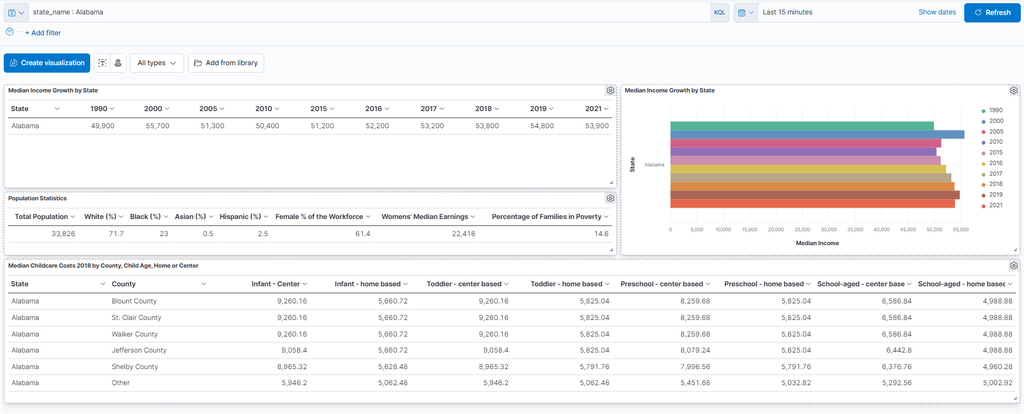

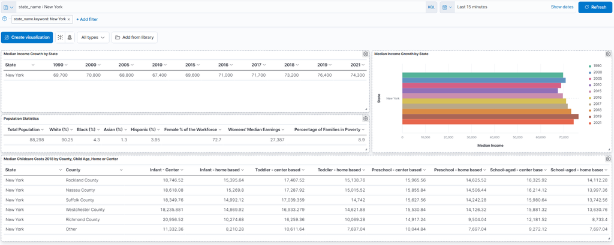

#### The second dashboard allows us to show employment and unemployment numbers for 2018 across multiple demographics, multiple age brackets, and broken down by full-time (FT) - by in the office more than 35hrs a week, less than 35hrs a week, and working from home - part-time(PT) in the office or WFH, and those unemployed, both seeking full-time and part-time work.

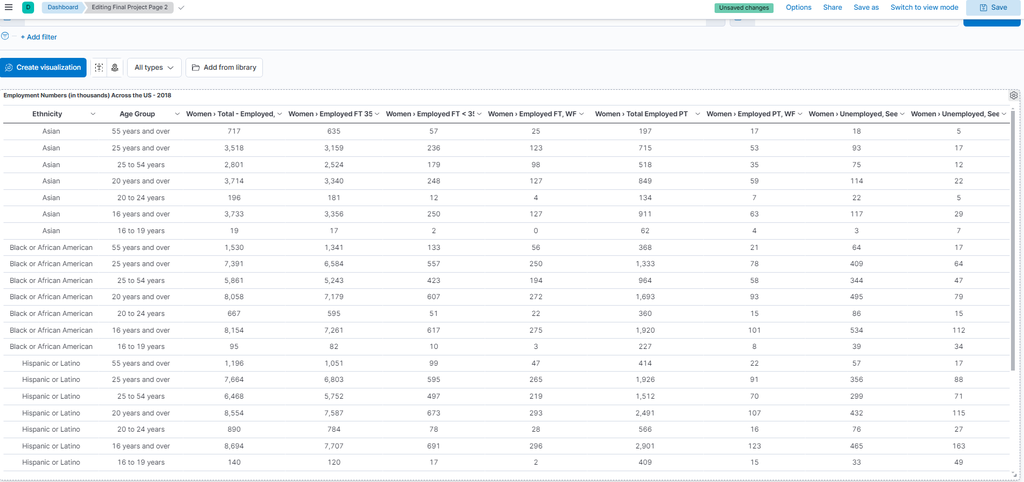

http://localhost:5601/goto/22b72dd0-ba68-11ef-9f9e-8522fc70be96

#### Such a presentation of the data collected by the federal government not only provides a better snapshot of the economic situation of an individual state/county, but provides crucial information for families who may be looking at relocating.

# **Conclusions**

This project collected data from 3 different agencies across two different, federal departments: Bureau of Labor Statistics (Department of Labor); Department of Labor; and National Center for Education Studies (Department of Education's Institute of Education Sciences).

To truly provide citizens with realistic expectations of their financial situations, given their circumstances and a particular state, future initiatives could be expanded to include: Tax statistics from the Internal Revenue Service (Department of the Treasury) State tax requirements from the Office of Tax Analysis (Department of the Treasury) Cost of Living from the Bureau of Labor Statistics (Department of Labor) Veterans' Employment / Unemployment rates from the Department of Veteran's Affairs Life Expectancy from the National Center for Health Statistics, Centers for Disease Control (Department of Health & Human Services) Quality of Education (Department of Education)

### Challenges with this project included:

The US Census Bureau data is coded to change the file name each time it is saved to include the date (YYYY-MM-DDTxxxx) as part of the file name. As such, we were not able to automate it's download. Once downloaded, we found it was essentially a duplication of data we had from the other three. Therefore, it was saved but not utilized in the final product.

Each dataset had its own formatting, footnotes, multiple rows of headers (some with compounded headers), making the cleansing a complex process easier to handle through Spark than Cassandra.

Each department updates their data at different intervals, further complicating this project.

While we initially planned to use MongoDB, after reviewing the data, Cassandra was a more appropriate intermediate database.

We pulled all the worksheets out of the DOL into one dataset, but, upon further review, found that all of the additional sheets were simply repeating the data but specific for each state. We retained that data for future analyses, but only used the "All States" worksheet for our analysis and dashboard.

Because of the complexity of our project, the final step of moving the dataframes into Elasticsearch turned out to be very challenging.